# IMM con R. Lab1: Análisis de Clasificación

Dra. Maite Mascaro y Dr. Edlin Guerra Castro

07/02/2023

Caso real: Contaminación en bentos por plataformas petroleras.

El siguiente caso de estudio fue publicado por **Gray JS, Clarke KR, Warwick RM, Hobbs G (1990)**. *Detection of initial effects of pollution on marine benthos: an example from the Ekofisk and Eldfisk oilfields, North Sea. Marine Ecology Progress Series 66, 285-299*. Este estudio consiste en la evaluación del macrobentos y varios contaminantes del sedimento en 39 sitios dispuestos en un diseño radial alrededor de una plataforma de perforación petrolera en el mar del Norte, donde se espera que los contaminantes asociados a la actividad petrolera afecten la estructura del ecosistema. La disposición de los sitios es circular, alejándose cada ciertos kilómetros del centro de perforación (@Fig1). Para esta actividad ignoraremos la distancia de cada sitio respecto a la plataforma. Intentaremos clasificar las muestras según sus descriptores, es decir, dejaremos que los datos cuenten su propia historia en vez de forzarlos a un modelo específico.

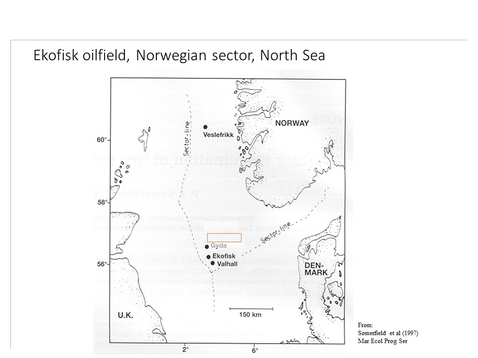

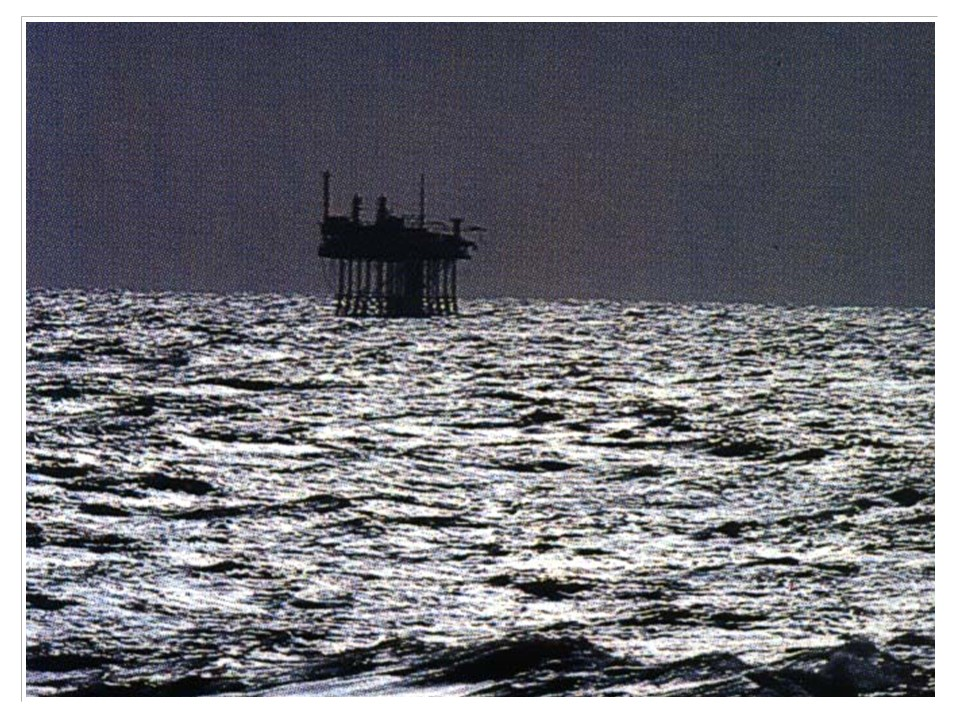

Plataforma Ekofisk

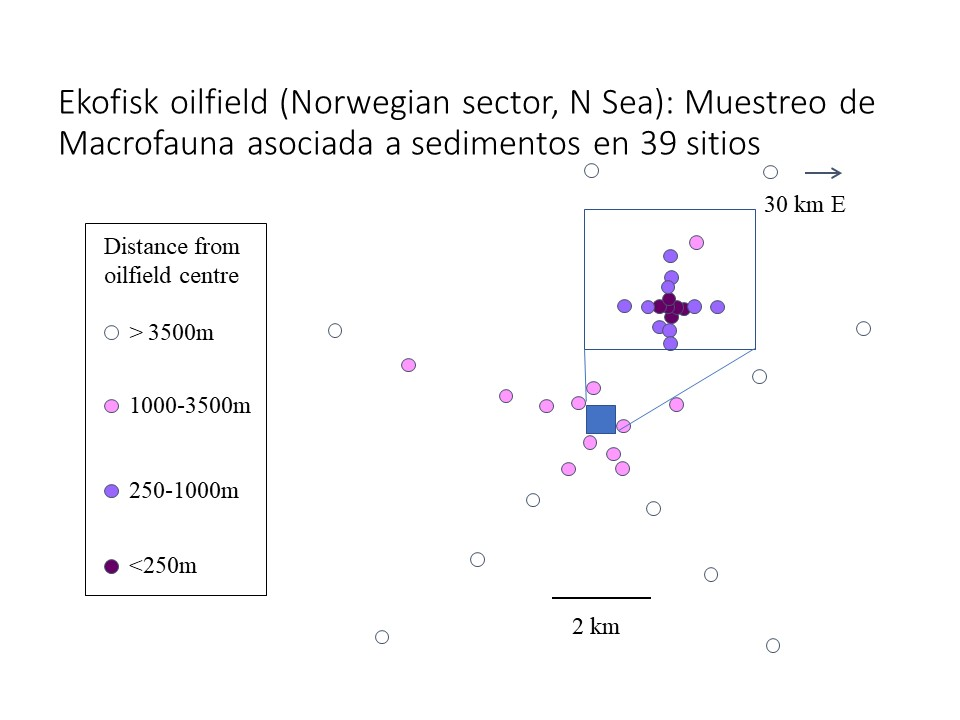

Diseño de muestreo radial

Figura 1. Plataforma de exploración petrolera Ekofisk :::